# Gap analysis

Ivan Gonzalez - igonzalez@humboldt.org.co

Wednesday, December 02, 2015

This is an code adaptation to develop an spatial gap index analysis *sensu* [*A methodological framework to quantify the spatial quality of biological databases*](http://www.biodiversity-plants.de/biodivers_ecol/article_meta.php?DOI=10.7809/b-e.00057)

The follow R code is an adaptation to get a final gap index map. For save the results in .PDF an .PNG please uncomment the lines starting with #pdf(, #png(, and #dev.off( in the ‘gapAnalysis.Rmd’ file

The first step is load information. For this is required to have both a database with biological records and the GIS layers. The GIS information can be retived from [climatic folder](https://drive.google.com/open?id=0B3J9l9VrPJBRTzV0Z0w5ZUd0bVE) and [bias factors](https://drive.google.com/open?id=0B3J9l9VrPJBRSjg1b3BEZDhETUE).

The datase must be ´data.frame´ class table with the follow columns: * Unique identifier * species name * latitude * longitude

We validate the original records in [taxonomical](https://github.com/LBAB-Humboldt/dataDownload) and [geographical](https://github.com/LBAB-Humboldt/GEOGRAPHICAL_VERIFICATIONS) way with available codes. For this reason we also incluide an *acceptedNameUsage* field. In order to replicate this analysis we recommend tho change the column names to showed below instead of changing script if you are not R user.

```r
DATOS <- read.csv('root/DATOS.csv', as.is = TRUE)
head(DATOS)
```

```
##    ID source   lat    lon                species     acceptedNameUsage
## 1 415   GBIF 12.55 -81.73    Passiflora suberosa   Passiflora suberosa
## 2 416   GBIF 12.58 -81.70      Scleria melaleuca     Scleria gaertneri
## 3 417   GBIF 12.58 -81.70    Eleocharis caribaea Eleocharis geniculata
## 4 419   GBIF 12.58 -81.70       Cyperus rotundus      Cyperus rotundus
## 5 421   GBIF 12.58 -81.70        Cyperus luzulae       Cyperus luzulae
## 6 423   GBIF 12.53 -81.72 Acalypha alopecuroidea                  <NA>
```

The subproduct derived from the script could take several minutes to be created. For this reason the most belated objects won’t be re-reprocessed if already exist in the outpath folder (**outPlotDir**). If you wan to create it again just remove them from containign folder or set a new outpath.

## 1. Data loading

The initial step is prepare data, paths and functions and load libraries.

```r
# ---------------------------
# 0.  Data loading
# ---------------------------
library(raster)
library(maptools)
library(rgdal)
library(SPECIES)
library(classInt)

source('root/GAPfunctions.R')
outPlotDir <- 'root/output'
ruta_factores <- 'root/GIS/FACTORES'
ruta_ambientales <- 'root/GIS/AMBIENTALES'


colombia <- readShapePoly(paste0(ruta_factores, "/COLOMBIA.shp"))
grilla <- raster(paste0(ruta_factores, "/grilla 10k.img"))
grilla[] <- 1:ncell(grilla)

en_area <- mask(grilla, colombia)

## Assign the pixel ID to each coordinate
DATOS2 <- DATOS[, c('ID', 'lat', 'lon')]
coordinates(DATOS2)=~lon+lat
celdas <- raster:::extract(en_area, DATOS2)
DATOS$celdas <- celdas

rm(celdas)
```

As result of this step we shold have a path’s to bias factor layers, climate layers and output plots and the follow objects: 1. Original table (DATOS) 2. Point polygon layer (DATOS2) 3. Polygon layer (mask) of the region of interest (colombia) 4. An ‘ID’ raster of area of interest (grilla) 5. ‘Masked’ ID raster with the polygon of area of interest (en_area) 6. A column indicating the pixel in which each pairs of coordinates over (‘celdas’ column in DATOS table)

## 2. Records density

As the article show, there’s tree components to calculet the gap index. The first is the record density and is estimated as the number of records over each pixel:

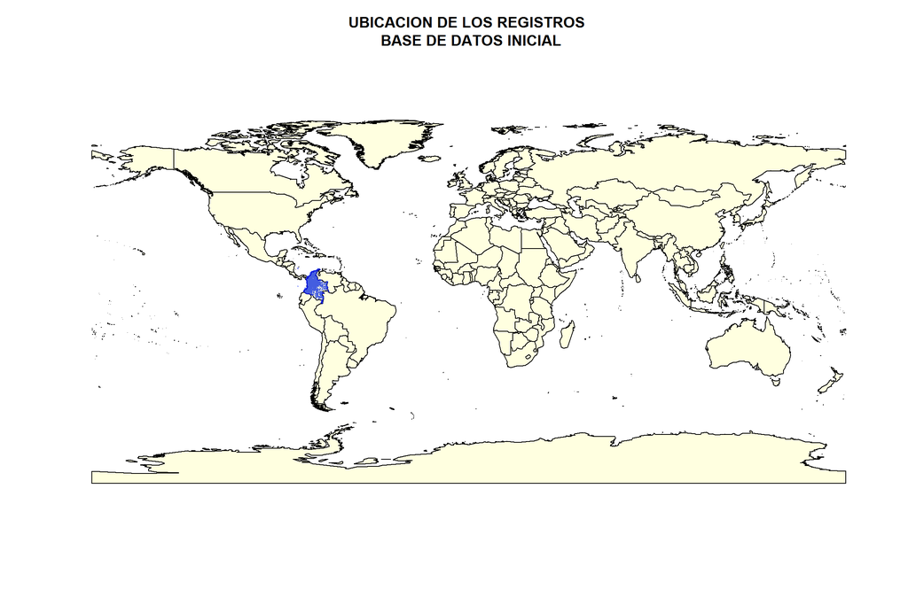

```r
# ---------------------------
# 1.  Records density
# ---------------------------

DATOS2$CONT <- 1
if (file.exists('INDICE_DENSIDAD.tif')){
  densRegistros <- raster('INDICE_DENSIDAD.tif')
} else {
  densRegistros <- rasterize(DATOS2, en_area, field = DATOS2$CONT, fun = sum, na.rm = TRUE)
  densRegistros[is.na(densRegistros[])] <- 0
  densRegistros <- mask(densRegistros, colombia, filename = "INDICE_DENSIDAD.tif", overwrite = TRUE)
}

if (file.exists('localidades.tif')){
  localidades <- raster('localidades.tif')
} else {
  localidades <- rasterize(DATOS2[, 'CONT'], en_area, fun = function(x, ...) {
    length(unique(na.omit(x)))
    }, filename = "localidades.tif")[[2]]
}

# Let's generate a png file with the density plot
data(wrld_simpl)
par(mfrow = c(1,1))

plot(wrld_simpl, main="UBICACION DE LOS REGISTROS \n BASE DE DATOS INICIAL", col = 'lightyellow')
points(x=coordinates(DATOS2)[, 1], y=coordinates(DATOS2)[, 2], col = rgb(0.1, 0.2, 1, 0.01), cex = .1, pch = 20)
```

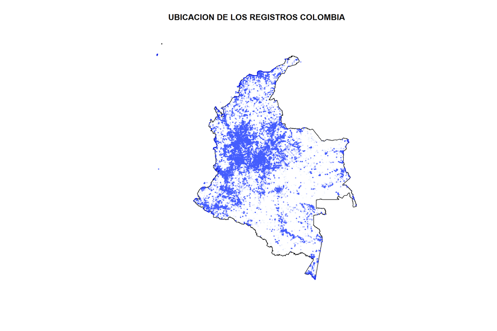

```r
plot(colombia, main = "UBICACION DE LOS REGISTROS COLOMBIA")
plot(DATOS2, add = TRUE, pch = 20, col = rgb(0.1, 0.2, 1, 0.01), cex = 0.5)
```

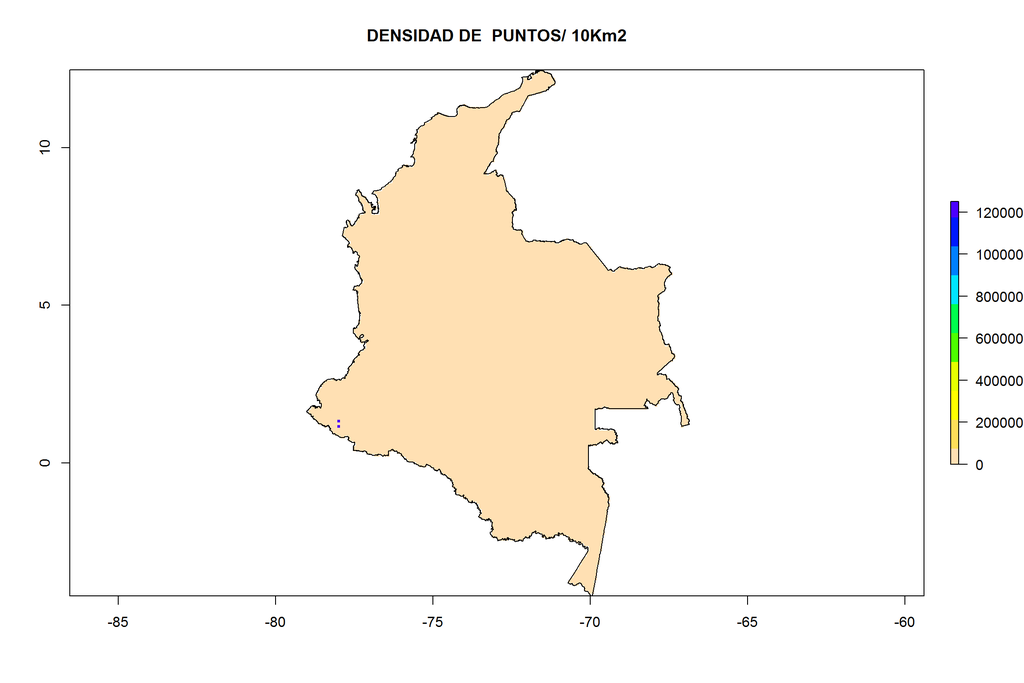

```r
plot(densRegistros, col = rev(topo.colors(10)), main="DENSIDAD DE  PUNTOS/ 10Km2")
plot(colombia, add = TRUE)
```

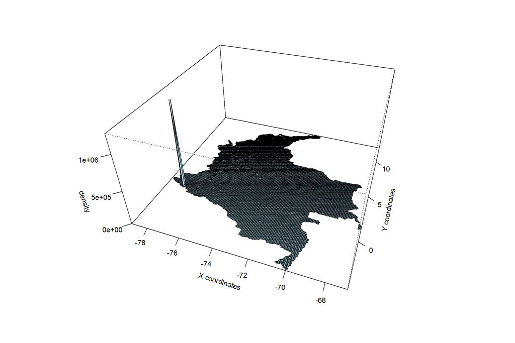

```r
persp(densRegistros, xlab = "X coordinates", ylab = "Y coordinates", zlab = "density",
      phi = 35, theta = 20, col = "lightblue", expand = .5, ticktype = "detailed")
```

In our data we oberve some points with hig-density that make a particular configuration of color ramp. For this we are gona to set the max value as the 95th percentile and observe in better scale the result. Note the diference in legend magnitude.

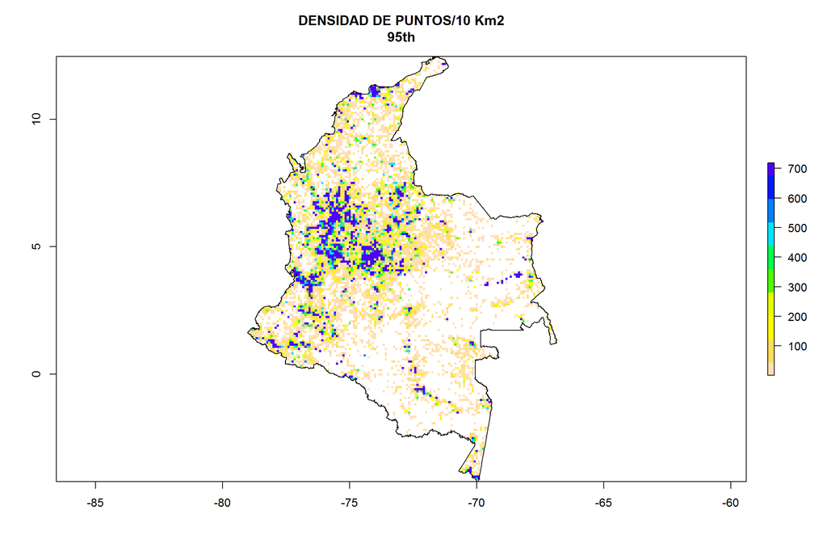

```r
q95 <- quantile(densRegistros, c(.95), na.rm = TRUE)
maxVal <- cellStats(densRegistros, 'max')
densRegistros2 <- reclassify(x = densRegistros, matrix(c(q95, maxVal, q95, 0, 0 , NA), nrow = 2, ncol = 3, byrow = TRUE),
                             filename = 'density95th.tif', overwrite = TRUE)
densRegistros2[densRegistros2[] == 0] <- NA
plot(densRegistros2, col = rev(topo.colors(10)), main = "DENSIDAD DE PUNTOS/10 Km2\n95th")
plot(colombia, add = TRUE)
```

## 3. Bias in sampling

The second element for the gap index is a bias layer. Section 2.

The follow code will show the bias as distance function taking some physical layers as reference. The result is just informative due will not take in account for GSI index estimation.

The third plot panel *bias* could be interpreted as a z-test score. In this sense values above 1.64 or bellow -1.64 indicate statistical diference in that category.

```r
# ---------------------------
# 2.  Bias in sampling
# ---------------------------
DATOS_s <- unique(DATOS[, c('lat', 'lon')])
N <- nrow(DATOS_s)

# ---------------------------
# 2.1 Bias by phisical factors
# ---------------------------
AP <- readOGR(ruta_factores, "protectedAreas")
urbano <- readOGR(ruta_factores, "urban")
rios <- readOGR(ruta_factores, "riversMain")
vias <- readOGR(ruta_factores, "roads")
```

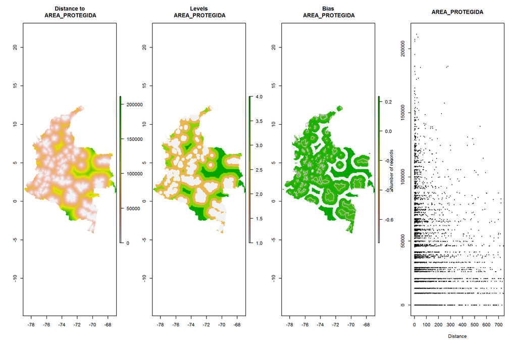

```r
sesgo_ap <- BIAS(biasLayer = AP, rasterMask = grilla, layerName = "AREA_PROTEGIDA",  outDir = outPlotDir)
```

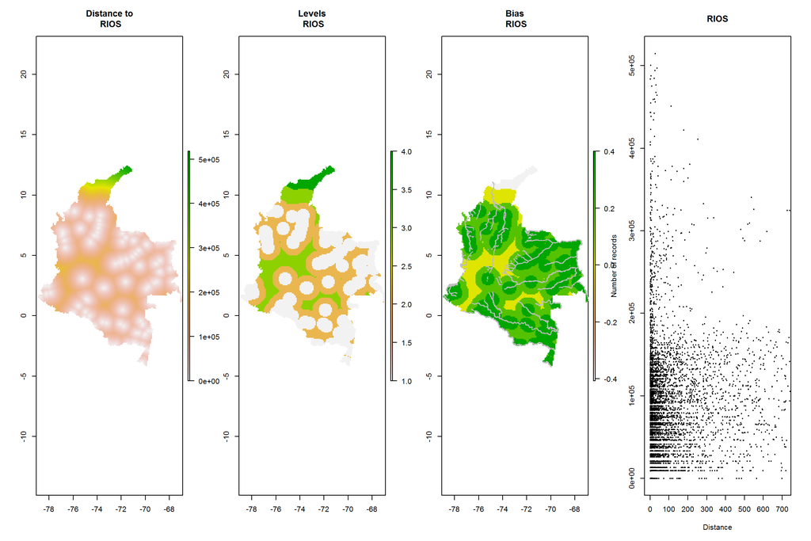

```r
sesgo_rios <- BIAS(biasLayer = rios, rasterMask = grilla, layerName = "RIOS",  outDir = outPlotDir)
```

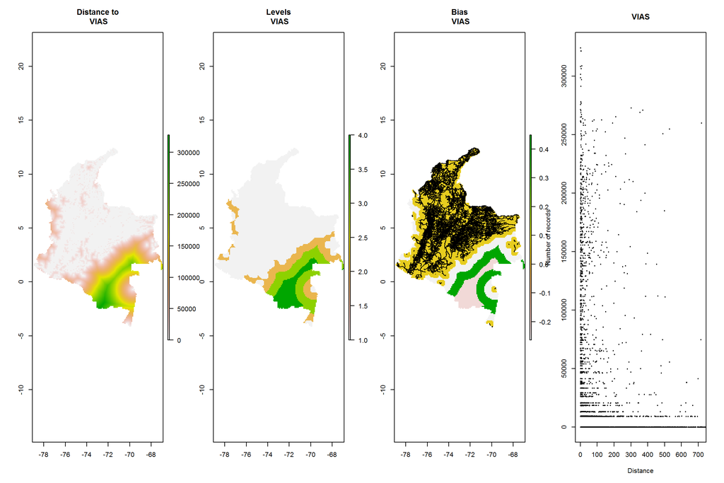

```r
sesgo_vias <- BIAS(biasLayer = vias, rasterMask = grilla,layerName = 'VIAS', outDir = outPlotDir)
```

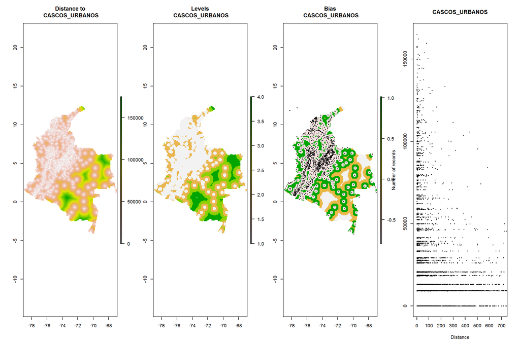

```r
sesgo_urbano <- BIAS(biasLayer = urbano, rasterMask = grilla, layerName = "CASCOS_URBANOS", outDir = outPlotDir)
```

```r
# Remove extra files and keep sesgo_ap, sesgo_rios, sesgo_vias, sesgo_urbano
rm(AP, urbano, rios, vias, DATOS_s, sesgo_ap, sesgo_rios, sesgo_vias, sesgo_urbano, grilla)
```

The follow code will show the bias usi climatic layers, slope and elevation as reference. The main result is the diference between the observed values for each layer given the coordinates *vs.* a random values. A kolmogorov test is used.

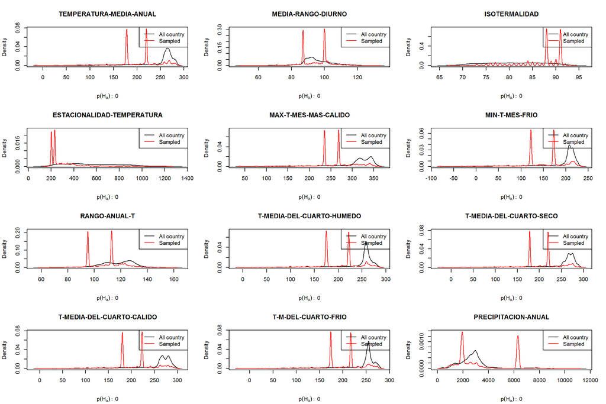

```r
# ---------------------------
# 2.2 Bias by environment
# ---------------------------

# 2.2.1 Compare distributions
## Compare environment all distribution values and sampled values by kolmogorov and Kullback-Leibler divergence

ambientales <- stack(paste0(ruta_ambientales, '/', c(paste0("bio_", 1:19), "alt", "slope")))
envVarNames <- c("TEMPERATURA-MEDIA-ANUAL", "MEDIA-RANGO-DIURNO", "ISOTERMALIDAD", "ESTACIONALIDAD-TEMPERATURA",
             "MAX-T-MES-MAS-CALIDO", "MIN-T-MES-FRIO", "RANGO-ANUAL-T", "T-MEDIA-DEL-CUARTO-HUMEDO",
             "T-MEDIA-DEL-CUARTO-SECO", "T-MEDIA-DEL-CUARTO-CALIDO", "T-M-DEL-CUARTO-FRIO", "PRECIPITACION-ANUAL",
             "PP-MES-MAS-HUMEDO", "PP-MES-MAS-SECO", "PP-ESTACIONAL", "PP-CUARTO-HUMEDO", "PP-CUARTO-SECO",
             "PP-CUARTO-CALIDO", "PP-CUARTO-FRIO", "ALTURA", "PENDIENTE")


# Generate data.frame with all values
if (file.exists(paste0(outPlotDir, '/variablesDF.csv'))){
  VARIABLES <- read.csv(paste0(outPlotDir, '/variablesDF.csv'))
} else {
  VARIABLES <- ambientales[1:ncell(ambientales)]
  VARIABLES <- na.omit(VARIABLES)
  write.csv(VARIABLES, paste0(outPlotDir, '/variablesDF.csv'), row.names = FALSE)
}

# Generate data.frame with observed values
if (file.exists(paste0(outPlotDir, '/samplingDF.csv'))){
  MUESTREO <- read.csv(paste0(outPlotDir, '/samplingDF.csv'))
} else {
  MUESTREO <- extract(ambientales, DATOS2)
  MUESTREO <- na.omit(MUESTREO)
  write.csv(MUESTREO, paste0(outPlotDir, '/samplingDF.csv'), row.names = FALSE)
}

par(mfrow = c(4, 3))

numPredictors <- dim(ambientales)[3]
RESULT <- NULL

for (i in 1:numPredictors){

  # Generate a random vector of complete variable with sampled vector size
  sample.Var.i <- sample(VARIABLES[, i], nrow(MUESTREO), replace = T)

  # Compare both random and sampled vector
  COMPARACION <- ks.test(sample.Var.i, MUESTREO[, i], )

  VAR <- envVarNames[i]
  media_var <- mean(VARIABLES[, i])
  media_DATOS <- mean(MUESTREO[, i])
  des_var <- sd(VARIABLES[, i])
  des_DATOS <- sd(MUESTREO[, i])
  coefvar_var <- des_var/media_var
  coefvar_DATOS <- des_DATOS/media_DATOS
  D <- COMPARACION$statistic
  Pval <- COMPARACION$p.value
  if (Pval <= 0.05){
    DESICION <- "Equal distributions"
  } else {
    DESICION <- "Diferent distributions"
  }
  Nceldas <- ncell(VARIABLES[, i])
  PI <- as.data.frame(table(MUESTREO[, i])/nrow(MUESTREO))
  QTOTAL <- as.data.frame(table(VARIABLES[, i])/Nceldas)
  QI <- QTOTAL[match(PI[, 1], QTOTAL[, 1]), ]

  Q <- cbind(QI[, 2], PI[, 2])
  Q <- as.matrix(Q)
  #KLdiv(Q,overlap=F, method="discrete")
  #DIVERGENCIA=KLdiv(Q,overlap=F,method="discrete",na.rm=T)[1,2]

  DENSI_VAR <- density(VARIABLES[, i])
  DENSI_MUES <- density(MUESTREO[, i])
  minx <- min(min(DENSI_VAR$x), min(DENSI_MUES$x))
  maxx <- max(max(DENSI_VAR$x), max(DENSI_MUES$x))
  miny <- min(min(DENSI_VAR$y), min(DENSI_MUES$y))
  maxy <- max(max(DENSI_VAR$y), max(DENSI_MUES$y))

  plot(density(VARIABLES[,i]), col='black', xlab = '', main=VAR, xlim=c(minx, maxx), ylim=c(miny,maxy),
       sub = bquote(p(H[a]):  ~ .(Pval)))
  lines(density(MUESTREO[,i]), col= "red", main=VAR)
  legend('topright', lty = c(1, 1), col = c('black', 'red'), legend = c('All country', 'Sampled'))
  RESUMEN <- cbind(VAR, media_var, media_DATOS, des_var, des_DATOS, coefvar_var, coefvar_DATOS,
                   D, Pval, DESICION)
  RESULT <- rbind(RESULT, RESUMEN)
}
```

```r
# Write table with summary for each variable
write.csv(RESULT, "goodness_fit.csv", row.names = FALSE)

# Remove extra objects
rm(MUESTREO, VARIABLES, RESULT, RESUMEN, VAR, media_var, media_DATOS, des_var, des_DATOS, coefvar_var, coefvar_DATOS,
   D, Pval, DESICION, DENSI_VAR, DENSI_MUES, sample.Var.i, Q, QI, QTOTAL)
```

[figure not shown]

The climate bias layer will be estiated using `BIAS()` function for each variable. Finally all **bias** layers are sumed.

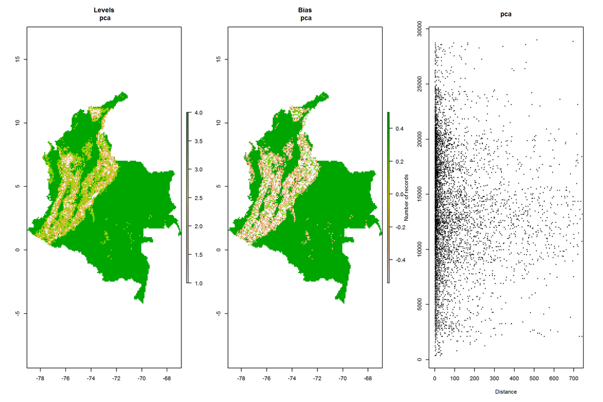

```r
# 2.2.2. Environmental bias layer

par(mfrow = c(1,2))
d <- ambientales[[1]] * 0
resultados <- NULL
sesgosDF <- NULL
for (k in 1:numPredictors){
  ses_amb <- BIAS(biasLayer = ambientales[[k]], layerName = envVarNames[k], outDir = outPlotDir, doplot = TRUE)
  d <- sum(d, ses_amb$biasLayer, na.rm = TRUE)
  sesgosDF <- cbind(sesgosDF, ses_amb$biasLayer[])
  resultados <- cbind(resultados, ses_amb$biasValues)
}
colnames(sesgosDF) <- names(resultados) <- envVarNames

pcaLayer <- raster(paste0(ruta_ambientales, '/pcaLayer.tif'))
ses_pca <- BIAS(biasLayer = pcaLayer, layerName = 'pca', outDir = outPlotDir, doplot = TRUE)
d2 <- ses_pca$biasLayer

write.table(resultados, "sesgos_ambientales.txt", sep="\t", col.names = TRUE)
write.table(sesgosDF, "sesgos_tabla_Capas.txt", sep="\t", col.names = TRUE)
writeRaster(d, "INDICE_AMBIENTAL.tif", overwrite = TRUE)
```

## 4. Data base completness

The final component is the species completness. For this case we are gonna to use Jackknife and bootstrap estimates for two databse columns: original species and accepted species name.

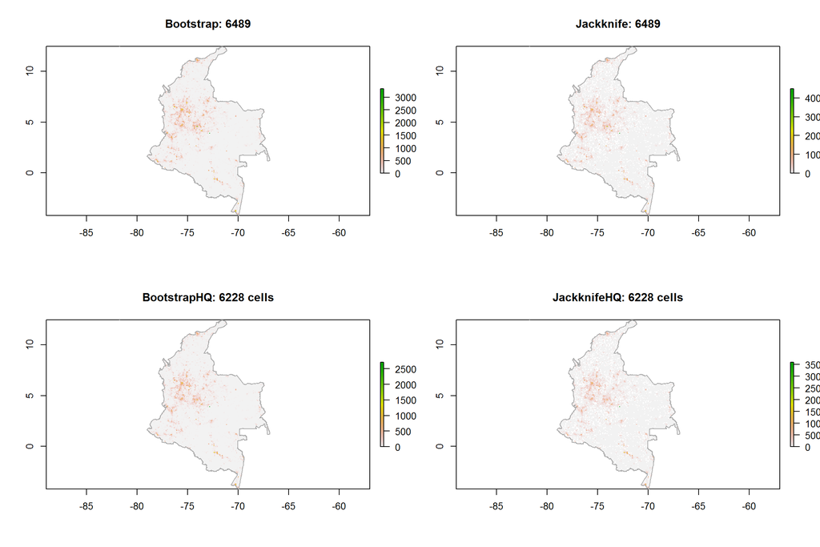

```r
# ---------------------------
# 3. Data base completness
# ---------------------------

spListByCell <- DATOS[!is.na(DATOS$celdas), c('species', 'celdas')]
spListByCellHQ <- DATOS[!is.na(DATOS$celdas) & !is.na(DATOS$acceptedNameUsage), c('acceptedNameUsage', 'celdas')]

freqTable <- table(spListByCell$celdas)
freqTableHQ <- table(spListByCellHQ$celdas)

treshold <- 0

spListByCell <- spListByCell[spListByCell$celdas %in% names(which(freqTable >= treshold)), ]
spListByCellHQ <- spListByCellHQ[spListByCellHQ$celdas %in% names(which(freqTableHQ >= treshold)), ]

estimateS <- richEst(sppList = spListByCell$species, indexID = spListByCell$celdas)
estimateSHQ <- richEst(spListByCellHQ$acceptedNameUsage, spListByCellHQ$celdas)

rm(spListByCell, spListByCellHQ)

compRichBoot <- compRichJack <- richJackHQ <- richBootHQ <- richJack <- richBoot <- en_area * 0
richBoot[as.numeric(rownames(estimateS))] <- estimateS$Boot
richJack[as.numeric(rownames(estimateS))] <- estimateS$JNhat
richBootHQ[as.numeric(rownames(estimateSHQ))] <- estimateSHQ$Boot
richJackHQ[as.numeric(rownames(estimateSHQ))] <- estimateSHQ$JNhat

compRichBoot[as.numeric(rownames(estimateS))] <- estimateS$Sobs/estimateS$Boot
compRichJack[as.numeric(rownames(estimateS))] <- estimateS$Sobs/estimateS$JNhat

#compRichBoot[as.numeric(rownames(estimateS)[estimateS$Sobs == 1])] <- NA
#compRichJack[as.numeric(rownames(estimateS)[estimateS$Sobs == 1])] <- NA
compRichJack[compRichJack[] >= 1] <- 1
compRichBoot[compRichBoot[] >= 1] <- 1

par(mfrow=c(2, 2))
plot(richBoot, main = paste('Bootstrap:', nrow(estimateS)))
plot(colombia, add = TRUE, border = 'darkgrey')
plot(richJack, main = paste('Jackknife:', nrow(estimateS)))
plot(colombia, add = TRUE, border = 'darkgrey')
plot(richBootHQ, main = paste('BootstrapHQ:', nrow(estimateSHQ), 'cells'))
plot(colombia, add = TRUE, border = 'darkgrey')
plot(richJackHQ, main = paste('JackknifeHQ:', nrow(estimateSHQ), 'cells'))
plot(colombia, add = TRUE, border = 'darkgrey')
```

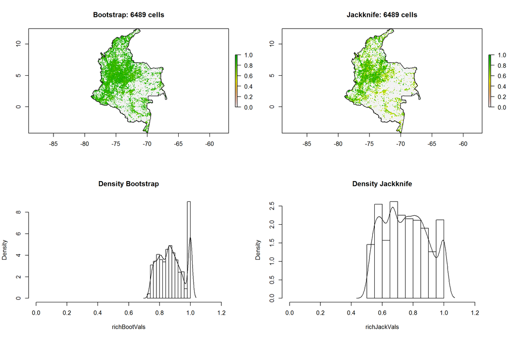

```r
plot(compRichBoot, main = paste('Bootstrap:', nrow(estimateS), 'cells'))
plot(colombia, add = TRUE)
plot(compRichJack, main = paste('Jackknife:', nrow(estimateS), 'cells'))
plot(colombia, add = TRUE)

richBootVals <- compRichBoot[!is.na(compRichBoot[]) & compRichBoot[] != 0]
richJackVals <- compRichJack[!is.na(compRichJack[]) & compRichJack[] != 0]
hist(richBootVals, main = 'Density Bootstrap', freq = FALSE, xlim = c(0, 1.2))
lines(density(richBootVals), main = 'Density Bootstrap')

hist(richJackVals, main = 'Density Jackknife', freq = FALSE, xlim = c(0, 1.2))
lines(density(richJackVals), main = 'Density Jackknife')
```

```r
writeRaster(compRichBoot, "INDICE_COMPLEMENTARIEDAD_JACK.tif", overwrite=TRUE)
writeRaster(compRichJack, "INDICE_COMPLEMENTARIEDAD_BOOTS.tif", overwrite=TRUE)
```

## 5. GSI/Gap selection index

Finally sum the three standardized components using the article formula

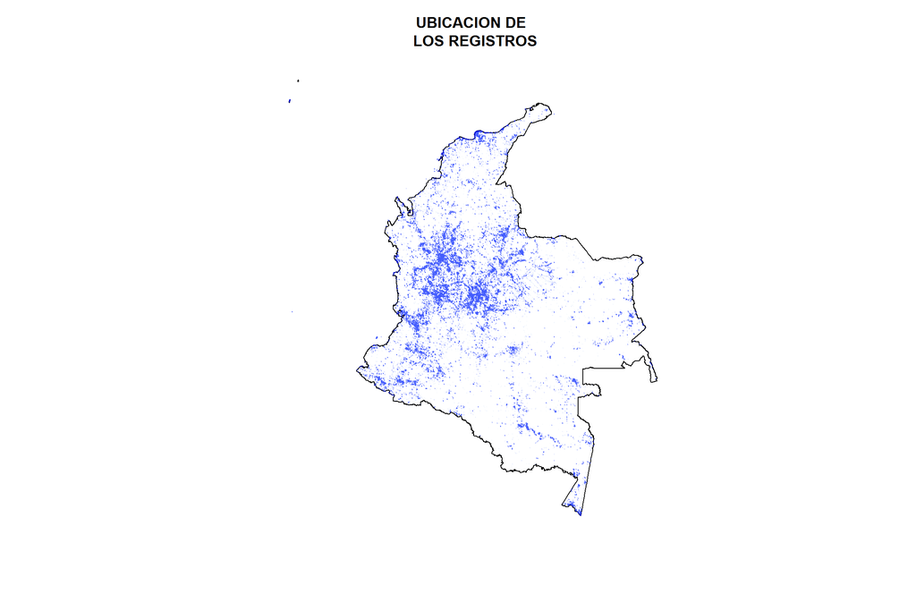

```r
# ---------------------------
# 4. GSI / Gap selection index
# ---------------------------

# Layer standardization

DENSIDAD <- normalize01(densRegistros)
AMBIENTAL <- normalize01(d)
COMP_BOOT <- normalize01(compRichBoot)
COMP_JACK <- normalize01(compRichJack)
COMP_JACK[is.na(COMP_JACK[])] <- 0

writeRaster(DENSIDAD,"INDICE_DENSIDAD_EST.tif", overwrite=TRUE)
writeRaster(AMBIENTAL,"INDICE_AMBIENTAL_EST.tif", overwrite=TRUE)
writeRaster(COMP_BOOT,"INDICE_COMPLEMENTARIEDAD_BOOT_EST.tif", overwrite=TRUE)
writeRaster(COMP_JACK,"INDICE_COMPLEMENTARIEDAD_JACK_EST.tif", overwrite=TRUE)

# Plot
## Records ubication

par(mfrow = c(1, 1))
plot(colombia, main = "UBICACION DE \n LOS REGISTROS")
plot(DATOS2, add = T, pch = 20, cex = 0.1, col = rgb(0.1, 0.2, 1, 0.01))
```

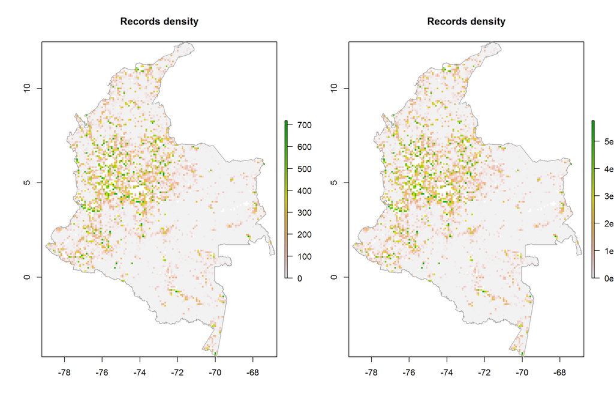

```r
## Records density
par(mfrow=c(1, 2))
plot(densRegistros, main = 'Records density', zlim = c(0, quantile(densRegistros[], .95, na.rm = TRUE)))
plot(colombia, add = TRUE, border = 'darkgrey')
plot(DENSIDAD, main = 'Records density', zlim = c(0, quantile(DENSIDAD[], .95, na.rm = TRUE)))
plot(colombia, add = TRUE, border = 'darkgrey')
```

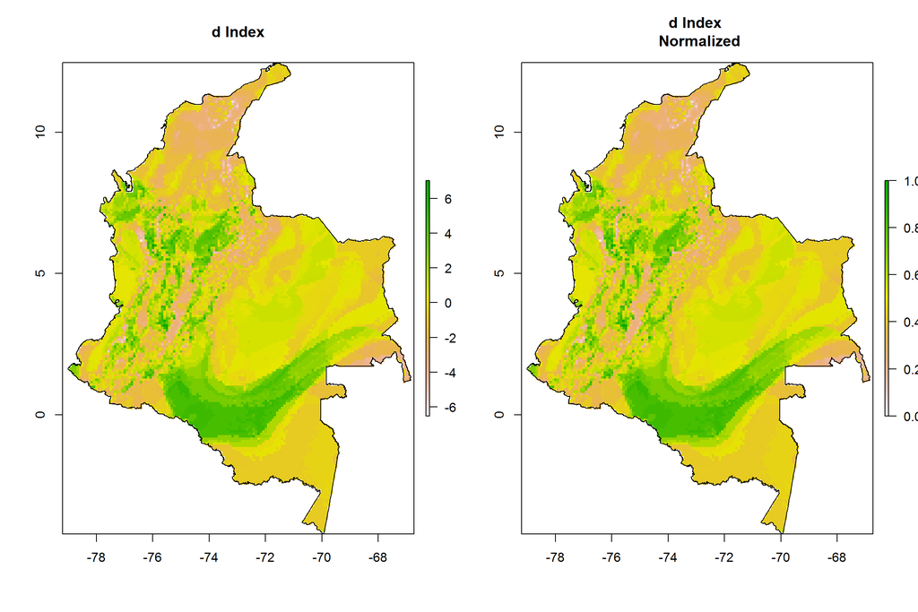

```r
## Environmental bias
par(mfrow = c(1, 2))
plot(mask(d, colombia), main = 'd Index')
plot(colombia, add = TRUE)
plot(mask(AMBIENTAL, colombia), main = 'd Index \n Normalized')
plot(colombia, add = TRUE)
```

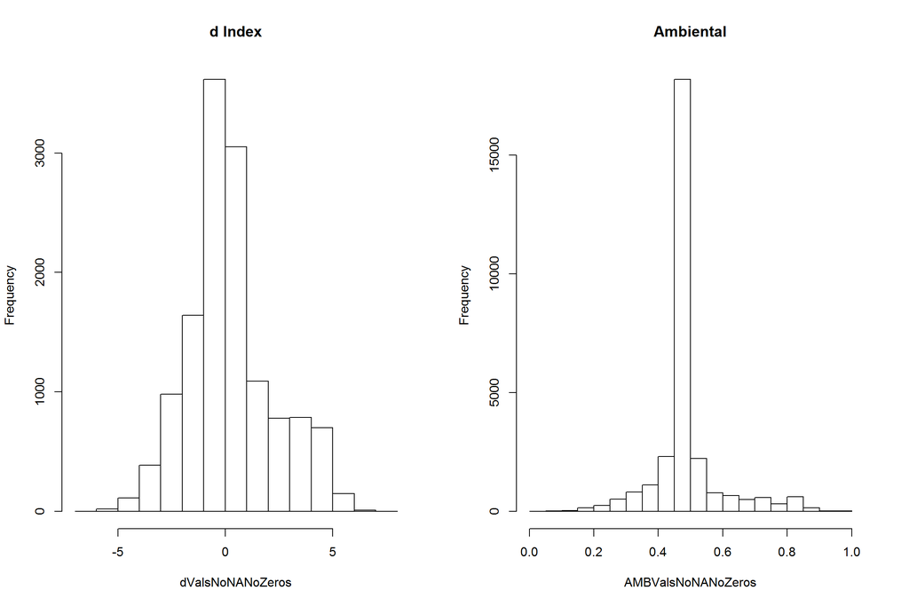

```r
par(mfrow = c(1, 2))
# dValsNoNA <- d[!is.na(d[])]
dValsNoNANoZeros <- d[!is.na(d[]) & d[] != 0]
# hist(dValsNoNA, main = 'd Index no NA no 0')
hist(dValsNoNANoZeros, main = 'd Index')

#AMBValsNoNA <- AMBIENTAL[!is.na(AMBIENTAL[])]
AMBValsNoNANoZeros <- AMBIENTAL[!is.na(AMBIENTAL[]) & AMBIENTAL[] != 0]
#hist(AMBValsNoNA, main = 'Ambiental no NA')
hist(AMBValsNoNANoZeros, main = 'Ambiental')
```

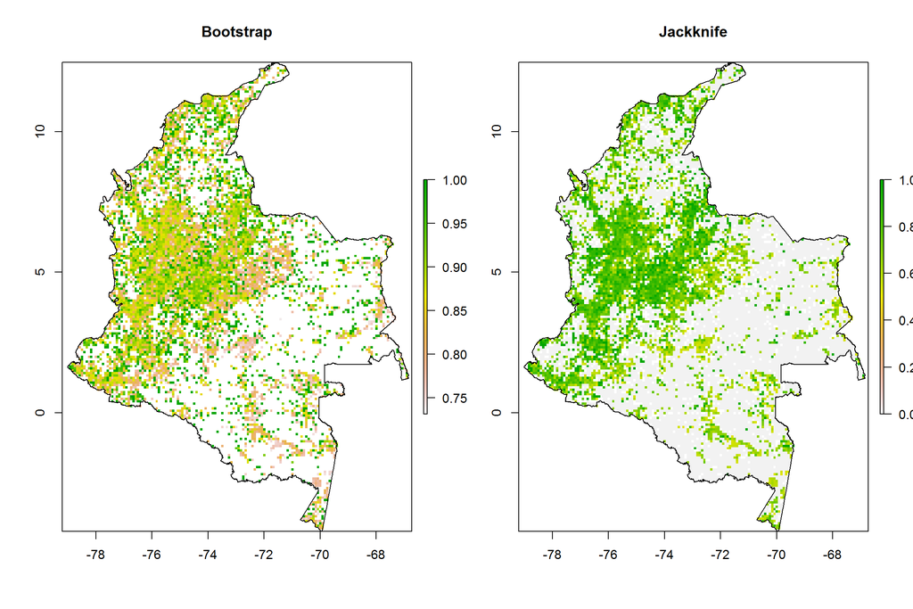

```r
## Completness
par(mfrow = c(1, 2))
compRichBoot[compRichBoot[] == 0] <- NA
plot(compRichBoot, main = 'Bootstrap')
plot(colombia, add = TRUE)
plot(compRichJack, main = 'Jackknife')
plot(colombia, add = TRUE)
```

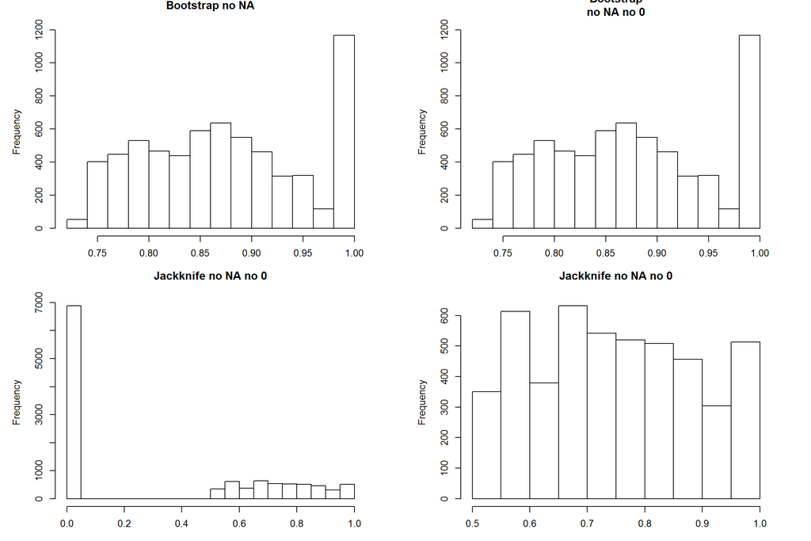

```r
par(mfrow=c(2, 2))

bootValsNoNA <- compRichBoot[!is.na(compRichBoot[])]
bootValsNoNANoZeros <- compRichBoot[!is.na(compRichBoot[]) & compRichBoot[] != 0]
hist(bootValsNoNA, main = 'Bootstrap no NA')
hist(bootValsNoNANoZeros, main = 'Bootstrap\nno NA no 0')

JacValsNoNA <- compRichJack[!is.na(compRichJack[])]
JacValsNoNANoZeros <- compRichJack[!is.na(compRichJack[]) & compRichJack[] != 0]
hist(JacValsNoNA, main = 'Jackknife no NA no 0')
hist(JacValsNoNANoZeros, main = 'Jackknife no NA no 0')

#  GSI / GAP INDEX
GSI_BOOT <- (3 - DENSIDAD - AMBIENTAL - COMP_BOOT)/3
GSI_JACK <- (3 - DENSIDAD - AMBIENTAL - COMP_JACK)/3

par(mfrow = c(1, 2))
```

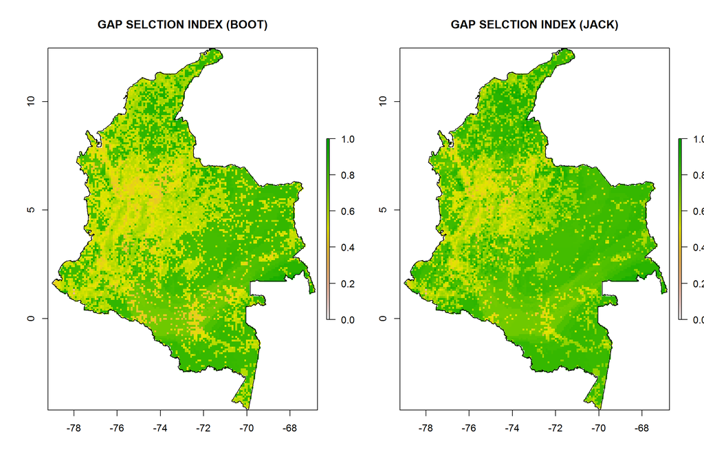

```r
plot(GSI_BOOT, main = 'GAP SELCTION INDEX (BOOT)', zlim = c(0, 1))
plot(colombia, add = TRUE)

plot(GSI_JACK, main = 'GAP SELCTION INDEX (JACK)', zlim = c(0, 1))
plot(colombia, add = TRUE)
```

```r
densJack <- density(GSI_JACK, main = 'Jackk', xlim = c(0, 1))
densBoot <- density(GSI_BOOT, main = 'Boot', xlim = c(0, 1))
```

[figure not shown]

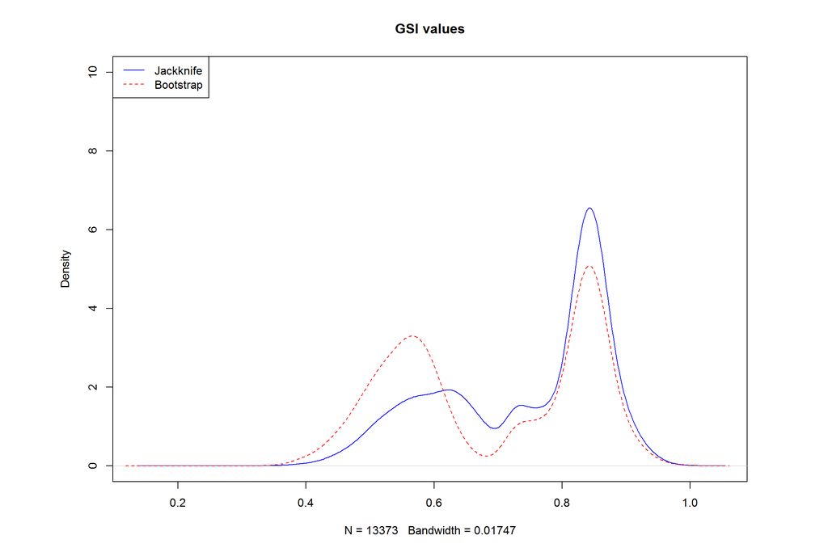

```r
par(mfrow = c(1, 1))
plot(densJack, main = 'GSI values', col = 'blue', ylim = c(0, 10), lty = 1)
lines(densBoot, col = 'red', lty = 2)
legend('topleft', legend = c('Jackknife', 'Bootstrap'),
       lty = c(1, 2), lwd = c(1, 1), col = c('blue', 2))
```

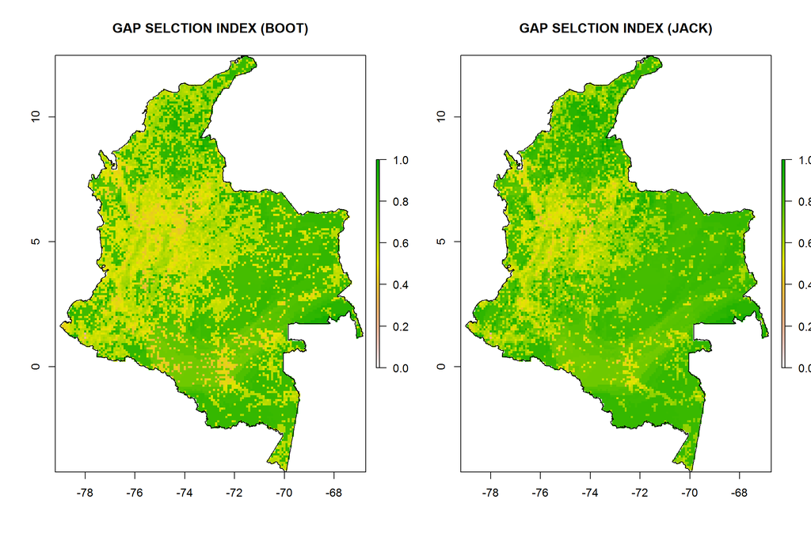

```r
writeRaster(GSI_BOOT,"INDICE_GSI_BOOT.tif", overwrite = TRUE)
writeRaster(GSI_JACK,"INDICE_GSI_JACK.tif", overwrite = TRUE)

par(mfrow = c(1, 2))
plot(GSI_BOOT, main = 'GAP SELCTION INDEX (BOOT)', zlim = c(0, 1))
plot(colombia, add = TRUE)

plot(GSI_JACK, main = 'GAP SELCTION INDEX (JACK)', zlim = c(0, 1))
plot(colombia, add = TRUE)
```